# observe of death in Taiwan 2013_2022 by ggplot

jerry

2025-05-30

This is a case study for my Google Data Analytics Professional Certificate ,and the theme is about mortality rate in Taiwan. In this file I will use steps in certificate to analyze death population in Taiwan by ggplot.

#Ask Population and age structure are huge issue for a country. Taiwan has the lowest fertility rate in 2024. Since we can’t increase the birth, I was wondering if I can find other ways to decrease population lose. So I need to know the situation about death people in Taiwan.

#Prepare

```r
library("dplyr")
```

```r
library("ggplot2")
library("tidyverse")
```

##Source of data **These data are from Government Information Open Platform, Ministry of Digital Affairs in Taiwan.** https://data.gov.tw/

death_toll_cause_of_death.csv https://data.gov.tw/dataset/123975

death_toll_group_by_age.csv https://data.gov.tw/dataset/125782

Data was download at 2025/05/30

The government update data once a year, so if you want the same data when I downloaded, here is the link:

death_toll_cause_of_death.csv https://drive.google.com/file/d/1ZS5SFK4tJXLnjzIXPaVpLraQ7GdBLXQn/view?usp=sharing

death_toll_group_by_age.csv https://drive.google.com/file/d/1-CTVEsOSbojYIQhdrSm3v1HCO6M4nqXP/view?usp=sharing

```r
setwd("C:/R/death")

death_toll_cause_of_death <- read.csv("death_toll_cause_of_death.csv", sep=",", header=TRUE, na = "NA")
death_toll_group_by_age <- read.csv("death_toll_group_by_age.csv", sep=",", header=TRUE,na = "NA")
```

#Process The column names’ description of data are from link of the original source of data, but these description is written by Chinese (Mandarian). So I need to translate into English.

```r
#cause_of_death

colnames(death_toll_cause_of_death) <- c("year","male_total","female_total",
                                         "male_cancer","female_cancer",
                                         "male_heart_disease","female_heart_disease",
"male_cerebrovascular_disease","female_cerebrovascular_disease",
                                         "male_diabetes","female_diabetes",
                                         "male_pneumonia","female_pneumonia",
                                         "male_kidney_disease","female_kidney_disease",
                                         "male_suicide","female_suicide",
                                         "male_accident_injury","female_accident_injury",
                                         "male_chronic_liver_disease","female_chronic_liver_disease",
                                         "male_hypertension","female_hypertension",
                                         "male_other","female_other")
##select data between 2013-2022
death_toll_cause_of_death <- death_toll_cause_of_death[8:17,]



#group by age
##delete duplicate column
death_toll_group_by_age <- select(death_toll_group_by_age,-4,-5)

colnames(death_toll_group_by_age) <- c("year","male_0","female_0","male_1_4","female_1_4",
                                       "male_5_14","female_5_14","male_15_24","female_15_24",
                                       "male_25_44","female_25_44","male_45_64","female_45_64",
                                       "male_65_older","female_65_older",
                                       "male_average_age","female_average_age",
                                       "male_median_age","female_median_age")
##select data between 2013-2022
death_toll_group_by_age <- death_toll_group_by_age[8:17,]
```

#Analyze and Share In order to make the chart by ggplot, I change the form of the data.

##polt1: As you see the plot1 below,both population (male and female) has increased over the years.

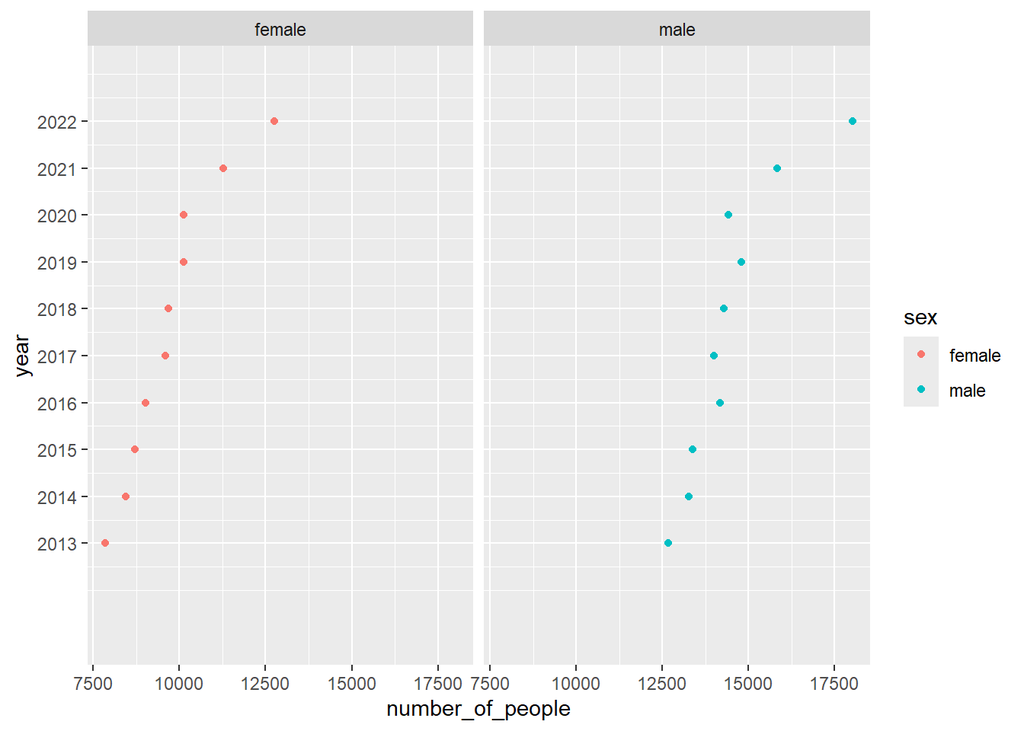

```r
polt1_male <- death_toll_cause_of_death[,c(1,2)]
polt1_male$sex <- c("male")
colnames(polt1_male) <- c("year","number_of_people","sex")

polt1_female <- death_toll_cause_of_death[,c(1,3)]
polt1_female$sex <- c("female")
colnames(polt1_female) <- c("year","number_of_people","sex")

polt1 <- rbind(polt1_male,polt1_female)

#make polt1
ggplot(data = polt1, aes(x=year,y=number_of_people))+
  geom_point(aes(color = sex))+
  scale_x_continuous(limits = c(2011,2023), breaks = seq(2013,2022,1))+
  facet_wrap(~sex)+
  coord_flip()
```

##data for plot2,plot3, and plot4 In plot2, plot3, and plot4, I want to know what is the main cause of the death of the group, so I combine different columns into 6 causes.

```r
data_for_plot2_3_4 <- death_toll_cause_of_death
death_toll_cause_of_death_sum <- colSums(death_toll_cause_of_death)
data_for_plot2_3_4 <- rbind(death_toll_cause_of_death,death_toll_cause_of_death_sum)
```

Plot 2 combine both male and female population,the main cause from high to low by % are: disease 38.12%, cancer 29.24%, other 24.41%, accident 3.07%, hypertension 2.66%, and suicide 2.51%.

##plot2

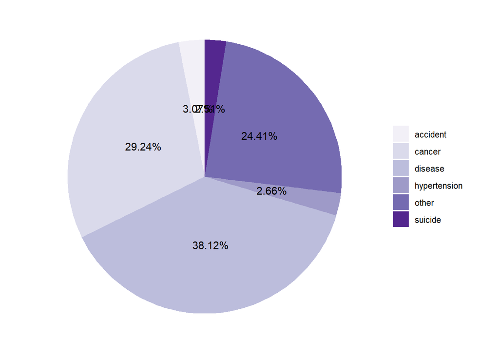

```r
plot2 <-data_for_plot2_3_4 %>% mutate(cancer = male_cancer + female_cancer,
                          disease = male_heart_disease + female_heart_disease+
                            male_cerebrovascular_disease + female_cerebrovascular_disease +
                            male_diabetes + female_diabetes + male_pneumonia + female_pneumonia +
                            male_kidney_disease + female_kidney_disease +
                          male_chronic_liver_disease + female_chronic_liver_disease,
                          suicide = male_suicide + female_suicide,
                          accident =  male_accident_injury + female_accident_injury,
                          hypertension = male_hypertension + female_hypertension,
                          other = male_other + female_other)
plot2 <- plot2[11,26:31]
plot2 <- data.frame(t(plot2),check.names=F)

cause <- c("cancer","disease","suicide","accident","hypertension","other")
plot2  <- cbind(cause,plot2)
colnames(plot2) <- c("cause","number_of_people")


#create pie chart
ggplot(plot2, aes(x="", y=number_of_people, fill = cause)) +
  geom_bar(stat="identity", width=1) +
  coord_polar("y", start=0) +
  geom_text(aes(label = paste0(round(number_of_people/242389*100,2), "%")), position = position_stack(vjust=0.5)) +
  labs(x = NULL, y = NULL, fill = NULL) +
  theme_classic() +
  theme(axis.line = element_blank(),
        axis.text = element_blank(),
        axis.ticks = element_blank()) +
  scale_fill_brewer(palette="Purples")
```

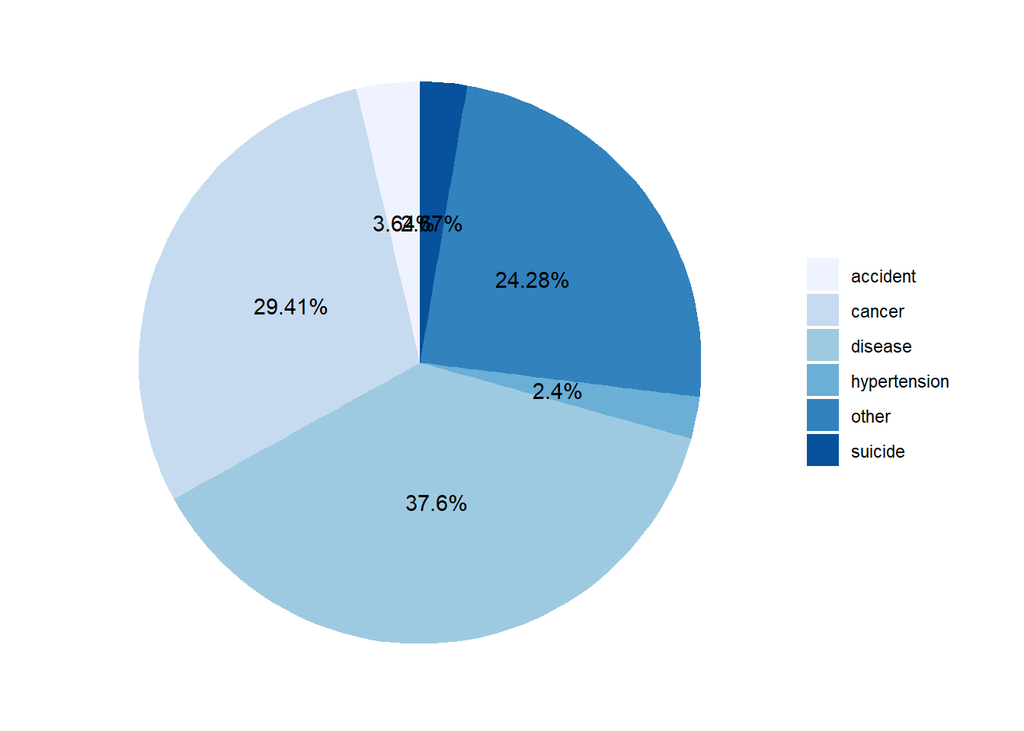

```r
##plot3_cause_of_death_in male
plot3 <-data_for_plot2_3_4 %>% mutate(cancer = male_cancer,
                                      disease = male_heart_disease +
                                        male_cerebrovascular_disease +
                                        male_diabetes + male_pneumonia +
                                        male_kidney_disease +
                                        male_chronic_liver_disease,
                                      suicide = male_suicide,
                                      accident =  male_accident_injury,
                                      hypertension = male_hypertension,
                                      other = male_other)
plot3 <- plot3[11,26:31]
plot3 <- data.frame(t(plot3),check.names=F)

cause <- c("cancer","disease","suicide","accident","hypertension","other")
plot3  <- cbind(cause,plot3)
colnames(plot3) <- c("cause","number_of_people")


#create pie chart
ggplot(plot3, aes(x="", y=number_of_people, fill = cause)) +
  geom_bar(stat="identity", width=1) +
  coord_polar("y", start=0) +
  geom_text(aes(label = paste0(round(number_of_people/144836*100,2), "%")), position = position_stack(vjust=0.5)) +
  labs(x = NULL, y = NULL, fill = NULL) +
  theme_classic() +
  theme(axis.line = element_blank(),
        axis.text = element_blank(),
        axis.ticks = element_blank()) +
  scale_fill_brewer(palette="Blues")
```

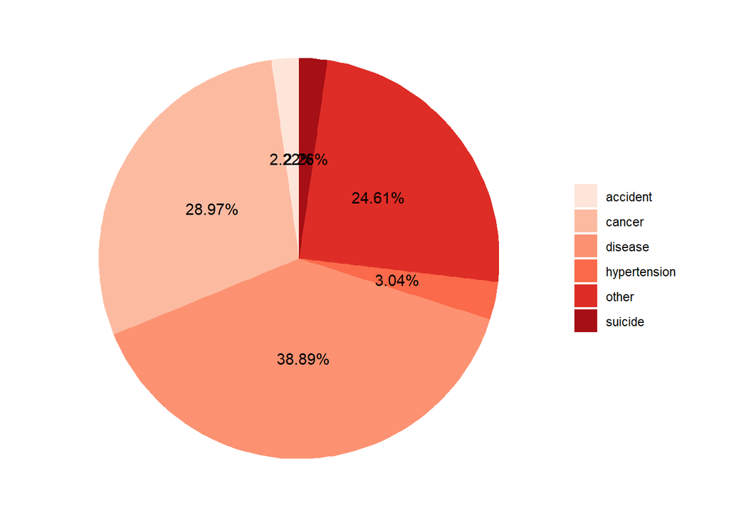

```r
##plot4_cause_of_death_in female
plot4 <-data_for_plot2_3_4 %>% mutate(cancer = female_cancer,
                                      disease = female_heart_disease +
                                      female_cerebrovascular_disease +
                                      female_diabetes + female_pneumonia +
                                      female_kidney_disease +
                                      female_chronic_liver_disease,
                                      suicide = female_suicide,
                                      accident =  female_accident_injury,
                                      hypertension = female_hypertension,
                                      other = female_other)
plot4 <- plot4[11,26:31]
plot4 <- data.frame(t(plot4),check.names=F)

cause <- c("cancer","disease","suicide","accident","hypertension","other")
plot4  <- cbind(cause,plot4)
colnames(plot4) <- c("cause","number_of_people")


#create pie chart
ggplot(plot4, aes(x="", y=number_of_people, fill = cause)) +
  geom_bar(stat="identity", width=1) +
  coord_polar("y", start=0) +
  geom_text(aes(label = paste0(round(number_of_people/97553*100,2), "%")), position = position_stack(vjust=0.5)) +
  labs(x = NULL, y = NULL, fill = NULL) +
  theme_classic() +
  theme(axis.line = element_blank(),
        axis.text = element_blank(),
        axis.ticks = element_blank()) +
  scale_fill_brewer(palette="Reds")
```

##plot5 The average age of death is increasing for both male and female population.

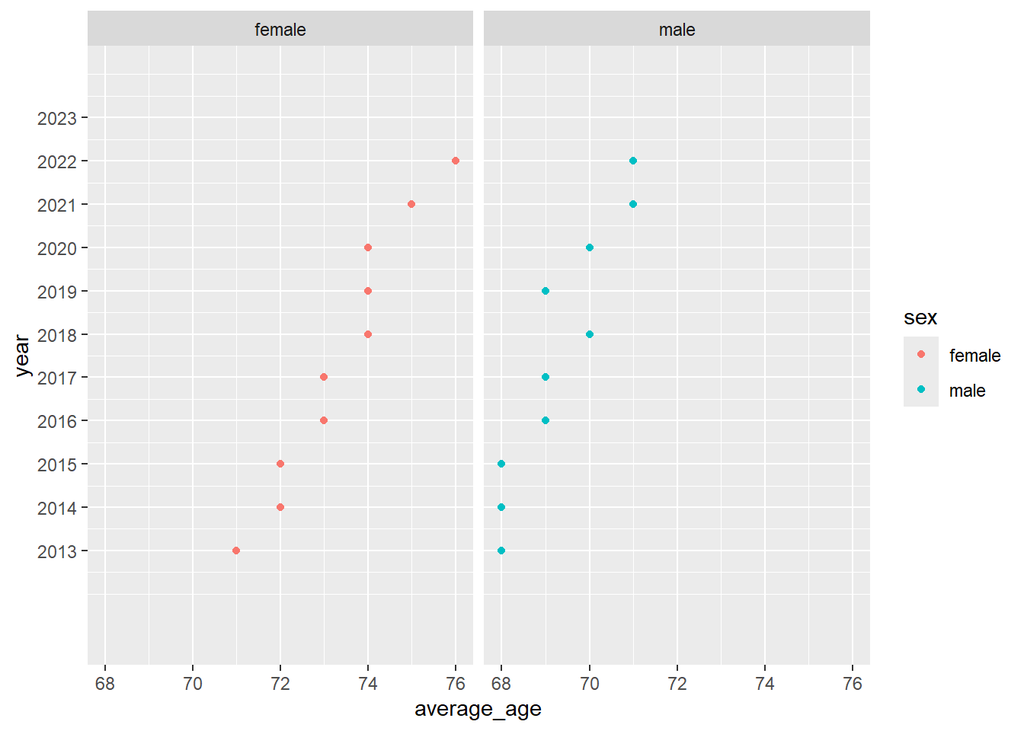

```r
death_toll_group_by_age$male_average_age <- as.integer(death_toll_group_by_age$male_average_age)
death_toll_group_by_age$female_average_age <- as.integer(death_toll_group_by_age$female_average_age)



plot5_male <- death_toll_group_by_age[,c(1,16)]
plot5_male$sex <- c("male")
colnames(plot5_male) <- c("year","average_age","sex")

plot5_female <- death_toll_group_by_age[,c(1,17)]
plot5_female$sex <- c("female")
colnames(plot5_female) <- c("year","average_age","sex")

plot5 <- rbind(plot5_male,plot5_female)

ggplot(data = plot5, aes(x=year,y=average_age))+
  geom_point(aes(color = sex))+
  scale_x_continuous(limits = c(2011,2024), breaks = seq(2013,2023,1))+
  facet_wrap(~sex)+
  coord_flip()
```

##data for plot6,plot7, and plot8 In plot6,plot7, and plot8, I separated population by young age population(0-14), Working age population(15-64), and Old age Population(>=65).

```r
data_for_plot6_7_8 <- death_toll_group_by_age[,2:15]
data_for_plot6_7_8_sum <- colSums(data_for_plot6_7_8)
data_for_plot6_7_8 <- rbind(data_for_plot6_7_8,data_for_plot6_7_8_sum)
```

##plot6 The population structure of death in 2013-2022 in Taiwan is: young age population(0-14) 0.78% Working age population(15-64) 29.96% Old age Population(>=65) 69.25%

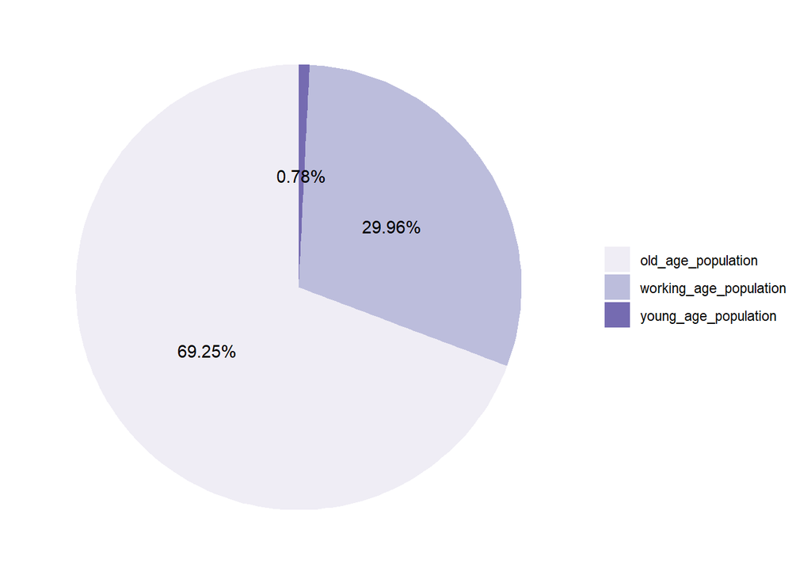

```r
plot6 <-data_for_plot6_7_8 %>% mutate(young_age_population =
                                        male_0 + female_0 +
                                        male_1_4 + female_1_4 +
                                        male_5_14 + female_5_14,
                                      working_age_population =
                                        male_15_24 + female_15_24 +
                                        male_25_44 + female_25_44 +
                                        male_45_64 + female_45_64,
                                      old_age_population =
                                        male_65_older + female_65_older)
plot6 <- plot6[11,15:17]
plot6 <- data.frame(t(plot6),check.names=F)

age_sturcture <- c("young_age_population","working_age_population","old_age_population")
plot6  <- cbind(age_sturcture,plot6)
colnames(plot6) <- c("age_sturcture","number_of_people")


ggplot(plot6, aes(x="", y=number_of_people, fill = age_sturcture)) +
  geom_bar(stat="identity", width=1) +
  coord_polar("y", start=0) +
  geom_text(aes(label = paste0(round(number_of_people/242455*100,2), "%")), position = position_stack(vjust=0.5)) +
  labs(x = NULL, y = NULL, fill = NULL) +
  theme_classic() +
  theme(axis.line = element_blank(),
        axis.text = element_blank(),
        axis.ticks = element_blank()) +
  scale_fill_brewer(palette="Purples")
```

##plot7 In male population: young age population(0-14) 0.75% Working age population(15-64) 34.14% Old age Population(>=65) 65.11%

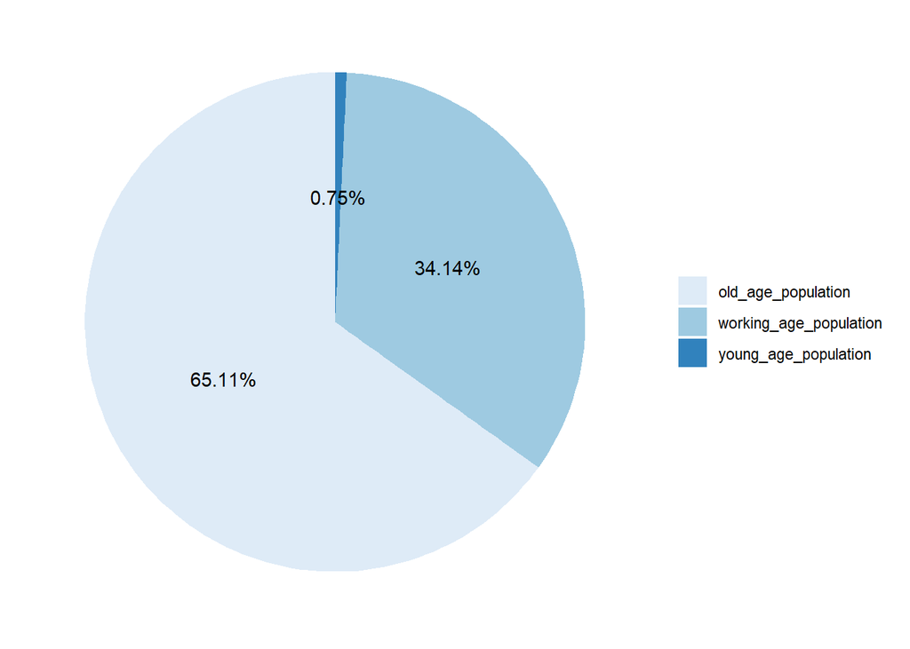

```r
plot7 <-data_for_plot6_7_8 %>% mutate(young_age_population =
                                          male_0 +
                                          male_1_4 +
                                          male_5_14,
                                        working_age_population =
                                          male_15_24 +
                                          male_25_44 +
                                          male_45_64,
                                        old_age_population =
                                          male_65_older)
plot7 <- plot7[11,15:17]
plot7 <- data.frame(t(plot7),check.names=F)

age_sturcture <- c("young_age_population","working_age_population","old_age_population")
plot7  <- cbind(age_sturcture,plot7)
colnames(plot7) <- c("age_sturcture","number_of_people")


ggplot(plot7, aes(x="", y=number_of_people, fill = age_sturcture)) +
  geom_bar(stat="identity", width=1) +
  coord_polar("y", start=0) +
  geom_text(aes(label = paste0(round(number_of_people/144900*100,2), "%")), position = position_stack(vjust=0.5)) +
  labs(x = NULL, y = NULL, fill = NULL) +
  theme_classic() +
  theme(axis.line = element_blank(),
        axis.text = element_blank(),
        axis.ticks = element_blank()) +
  scale_fill_brewer(palette="Blues")
```

##plot8 The percentage of old age population in female is higher than male. young age population(0-14) 0.83% Working age population(15-64) 23.76% Old age Population(>=65) 75.41%

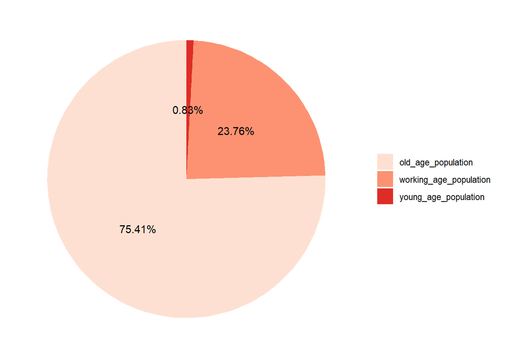

```r
plot8 <-data_for_plot6_7_8 %>% mutate(young_age_population =
                                          female_0 +
                                          female_1_4 +
                                          female_5_14,
                                        working_age_population =
                                          female_15_24 +
                                          female_25_44 +
                                          female_45_64,
                                        old_age_population =
                                          female_65_older)
plot8 <- plot8[11,15:17]
plot8 <- data.frame(t(plot8),check.names=F)

age_sturcture <- c("young_age_population","working_age_population","old_age_population")
plot8  <- cbind(age_sturcture,plot8)
colnames(plot8) <- c("age_sturcture","number_of_people")


ggplot(plot8, aes(x="", y=number_of_people, fill = age_sturcture)) +
  geom_bar(stat="identity", width=1) +
  coord_polar("y", start=0) +
  geom_text(aes(label = paste0(round(number_of_people/97555*100,2), "%")), position = position_stack(vjust=0.5)) +
  labs(x = NULL, y = NULL, fill = NULL) +
  theme_classic() +
  theme(axis.line = element_blank(),
        axis.text = element_blank(),
        axis.ticks = element_blank()) +
  scale_fill_brewer(palette="Reds")
```

The average age of death are more older, it may proof our medical system is become better. However, we still have to change our life style healthier to avoid get bed life quality of our lives.